# Fires Candice

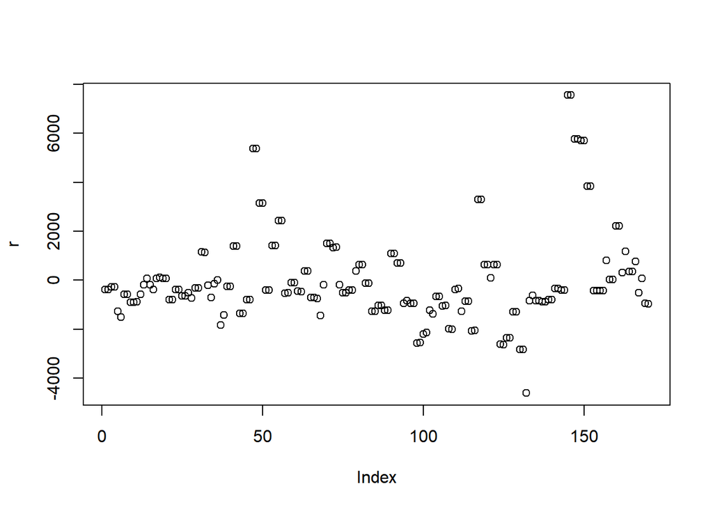

```r
r <- residuals(Reg8)
plot(r)
```

```r
Reg9 <- lm(Fires ~ r, data=Fires)
summary(Reg9)
```

```
##
## Call:
## lm(formula = Fires ~ r, data = Fires)
##
## Residuals:
##     Min      1Q  Median      3Q     Max
## -1.8487 -0.7651 -0.6298  0.2979 11.4052
##
## Coefficients:
##              Estimate Std. Error t value Pr(>|t|)
## (Intercept) 8.176e-01  1.154e-01   7.084 3.66e-11 ***
## r           1.365e-04  6.218e-05   2.196   0.0295 *
## ---
## Signif. codes:  0 '***' 0.001 '**' 0.01 '*' 0.05 '.' 0.1 ' ' 1
##
## Residual standard error: 1.505 on 168 degrees of freedom
## Multiple R-squared:  0.0279, Adjusted R-squared:  0.02211
## F-statistic: 4.821 on 1 and 168 DF,  p-value: 0.02948
```

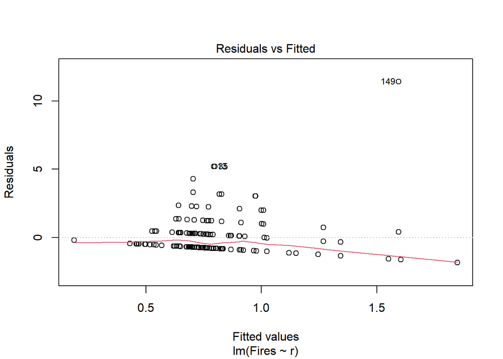

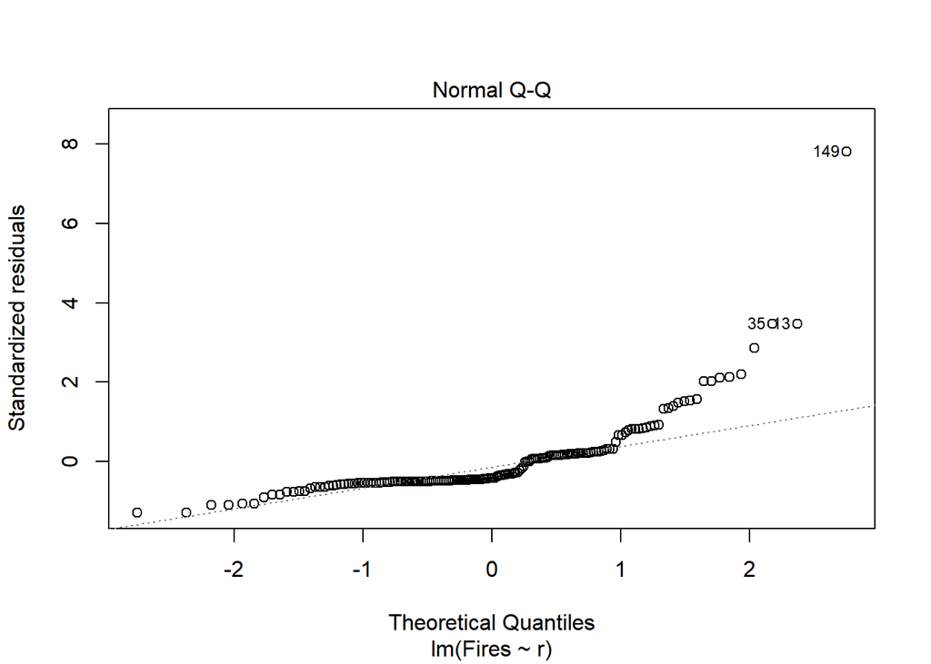

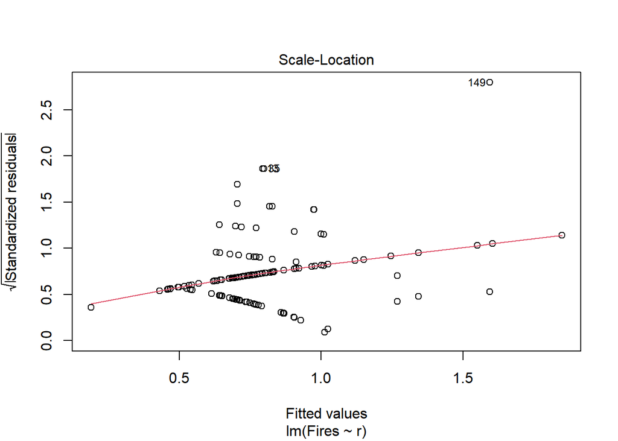

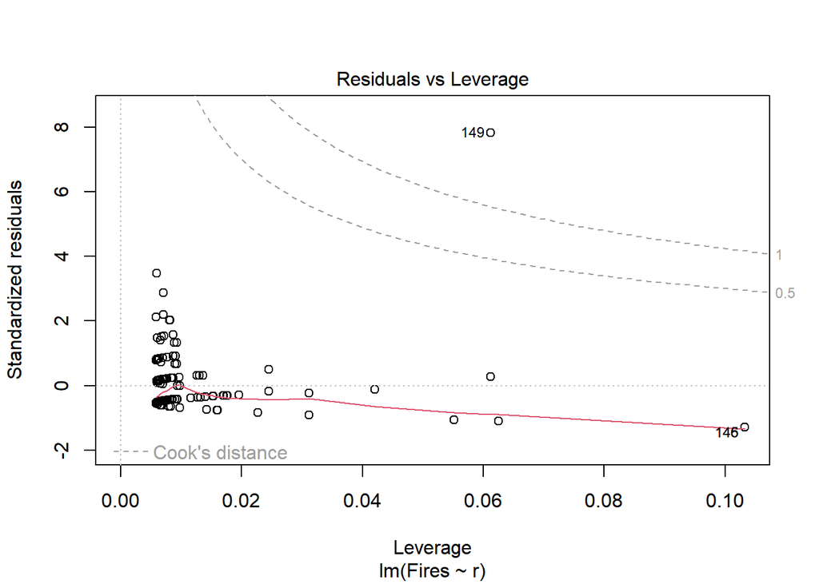

```r
plot(Reg9)
```

## Poisson model

First, I look at the mean to find the parameter.

```
## [1] 0.8176471
```

Then I plot the distribution and look at how it looks.

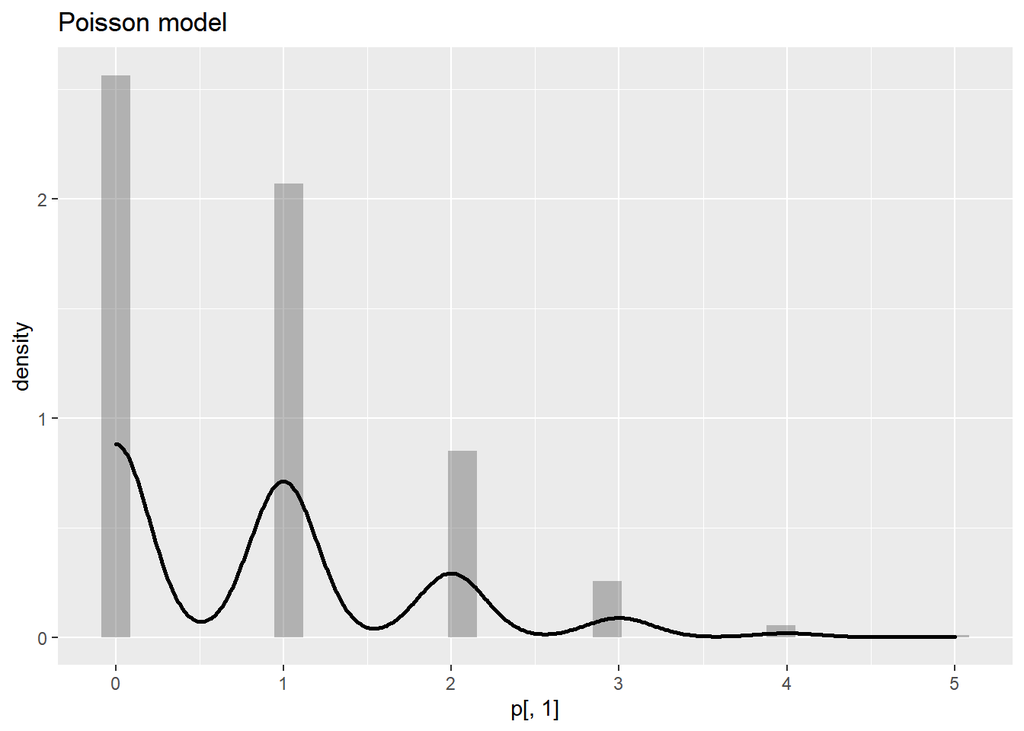

```r
p<-data.frame(rpois(10000,mean(Fires$Fires)))
ggplot(p,aes(x=p[,1]))+
  geom_histogram(aes(y=..density..), alpha=0.4, position="identity", lwd=0.1)+
  geom_density(alpha=0.3, lwd=1, bw=0.2)+
  ggtitle("Poisson model")
```

Trying to fit a Poisson model. The summary looks not so bad but the residuals are clearly not normal and there are some outliers.

```
##
## Call:
## glm(formula = Fires ~ Length + HGV + Traffic, family = "poisson",
##     data = Fires)
##
## Deviance Residuals:
##     Min       1Q   Median       3Q      Max
## -3.1274  -1.1442  -0.9460   0.4357   3.6053
##
## Coefficients:
##               Estimate Std. Error z value Pr(>|z|)
## (Intercept) -1.100e+00  1.561e-01  -7.049 1.80e-12 ***
## Length       8.732e-05  3.801e-05   2.297  0.02161 *
## HGV          3.286e+00  1.113e+00   2.953  0.00314 **
## Traffic      1.423e-09  2.020e-10   7.046 1.84e-12 ***
## ---
## Signif. codes:  0 '***' 0.001 '**' 0.01 '*' 0.05 '.' 0.1 ' ' 1
##
## (Dispersion parameter for poisson family taken to be 1)
##
##     Null deviance: 322.16  on 169  degrees of freedom
## Residual deviance: 257.70  on 166  degrees of freedom
## AIC: 434.77
##
## Number of Fisher Scoring iterations: 6
```

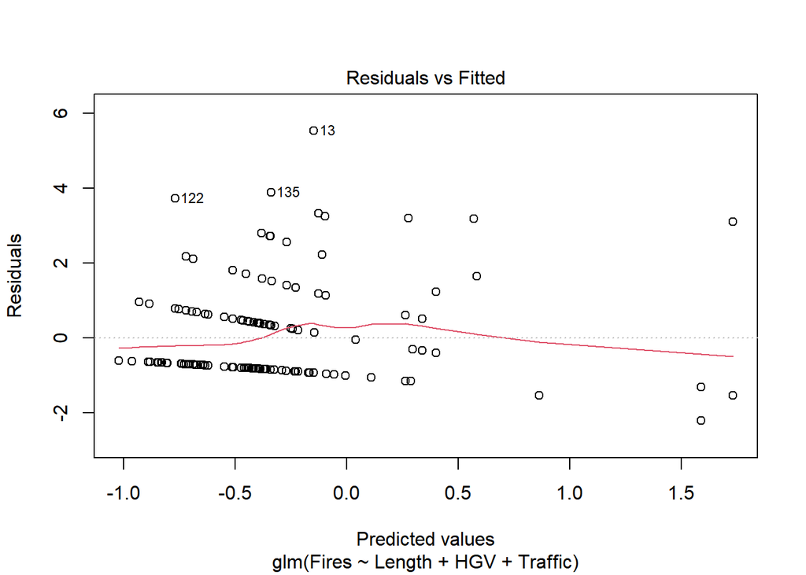

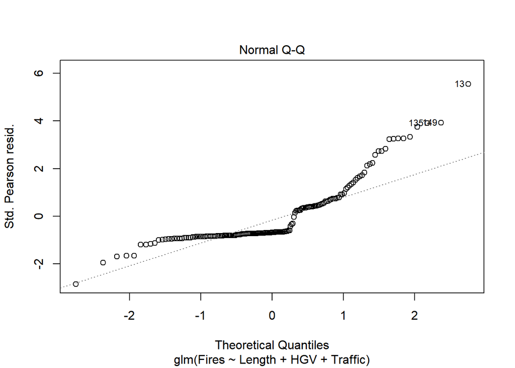

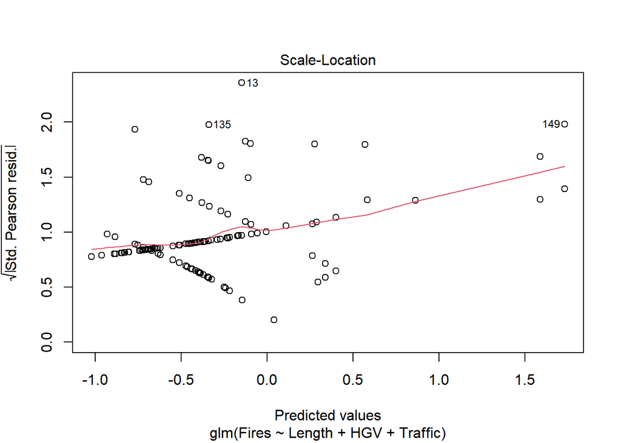

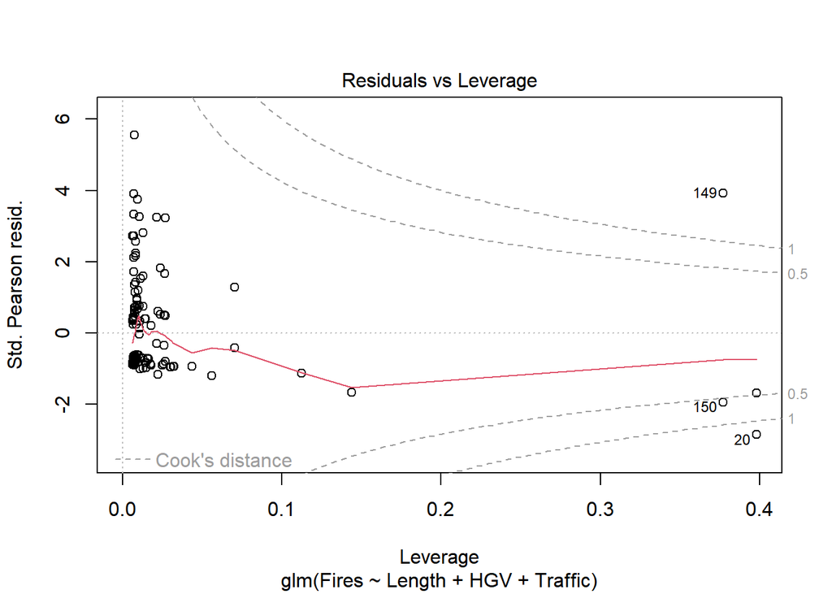

```
## [1] 434.7735
```

Second Poisson model : the summary is way better, I tried to plot the prediction but I am not sure I have understood what it does. Also the residuals look worse. The aic is slightly bigger.

```r
m2<- glm(Fires ~ HGV + Traffic, family="poisson", data=Fires)
summary(m2) #the summary looks pretty cool
```

```
##
## Call:
## glm(formula = Fires ~ HGV + Traffic, family = "poisson", data = Fires)
##
## Deviance Residuals:
##     Min       1Q   Median       3Q      Max
## -3.0681  -1.1763  -0.9203   0.3986   3.5276
##
## Coefficients:
##               Estimate Std. Error z value Pr(>|z|)
## (Intercept) -1.158e+00  1.600e-01  -7.239 4.52e-13 ***
## HGV          5.245e+00  7.132e-01   7.354 1.92e-13 ***
## Traffic      1.430e-09  2.059e-10   6.946 3.77e-12 ***
## ---
## Signif. codes:  0 '***' 0.001 '**' 0.01 '*' 0.05 '.' 0.1 ' ' 1
##
## (Dispersion parameter for poisson family taken to be 1)
##
##     Null deviance: 322.16  on 169  degrees of freedom
## Residual deviance: 262.88  on 167  degrees of freedom
## AIC: 437.95
##
## Number of Fisher Scoring iterations: 6
```

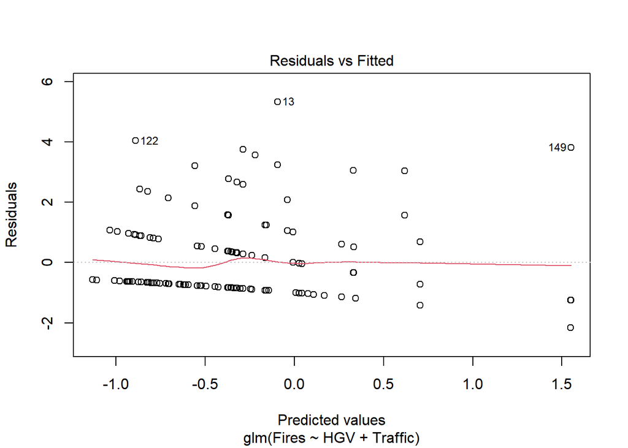

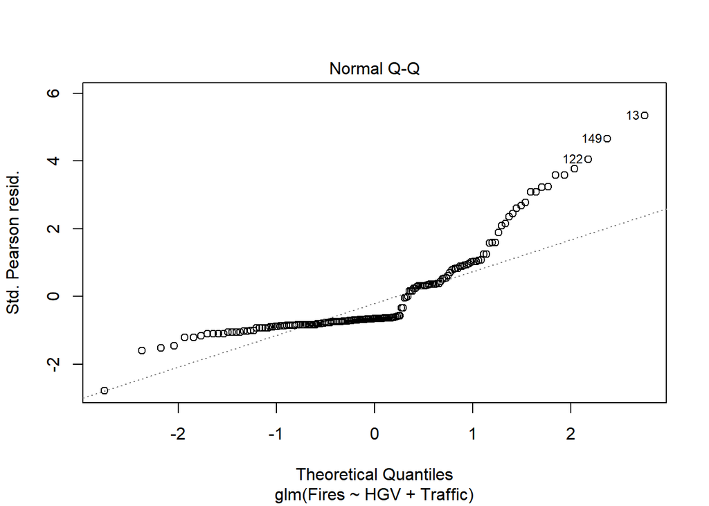

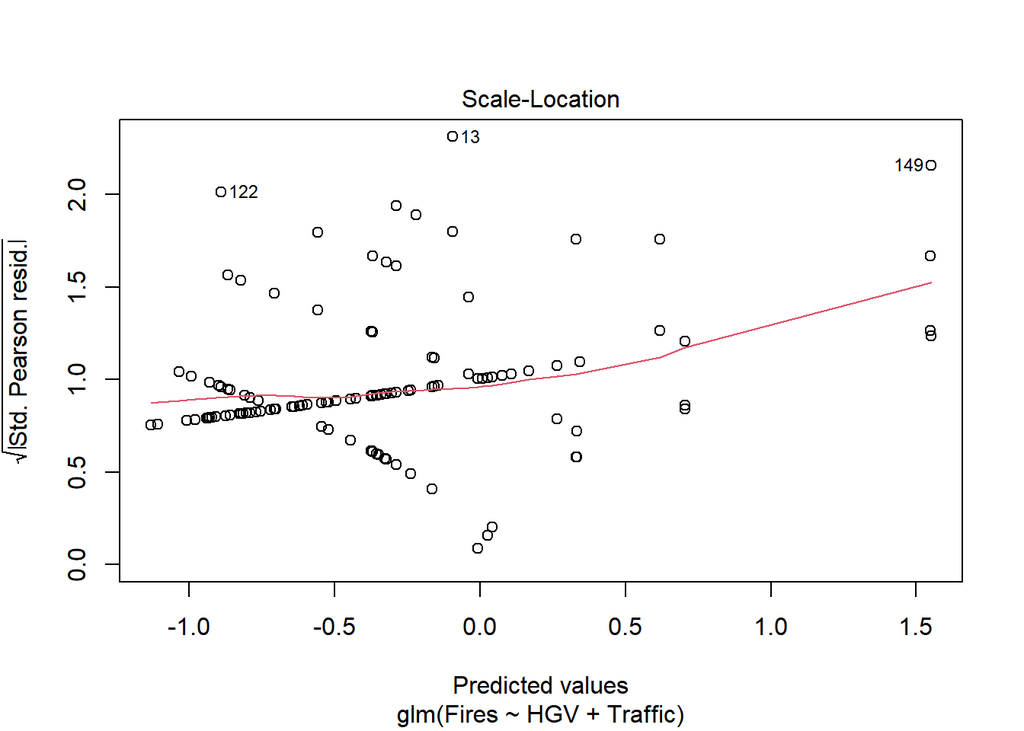

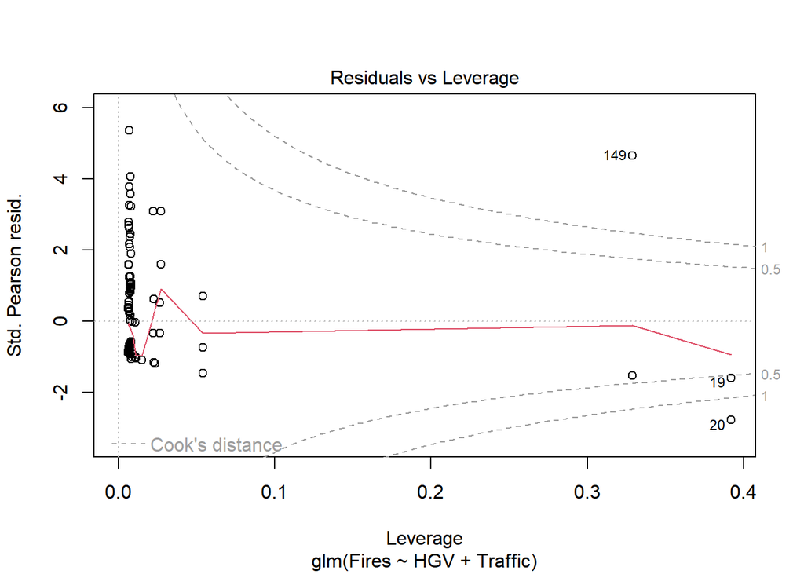

```r
plot(m2) #residuals are still bad
```

```r
m2$aic
```

```
## [1] 437.9527
```

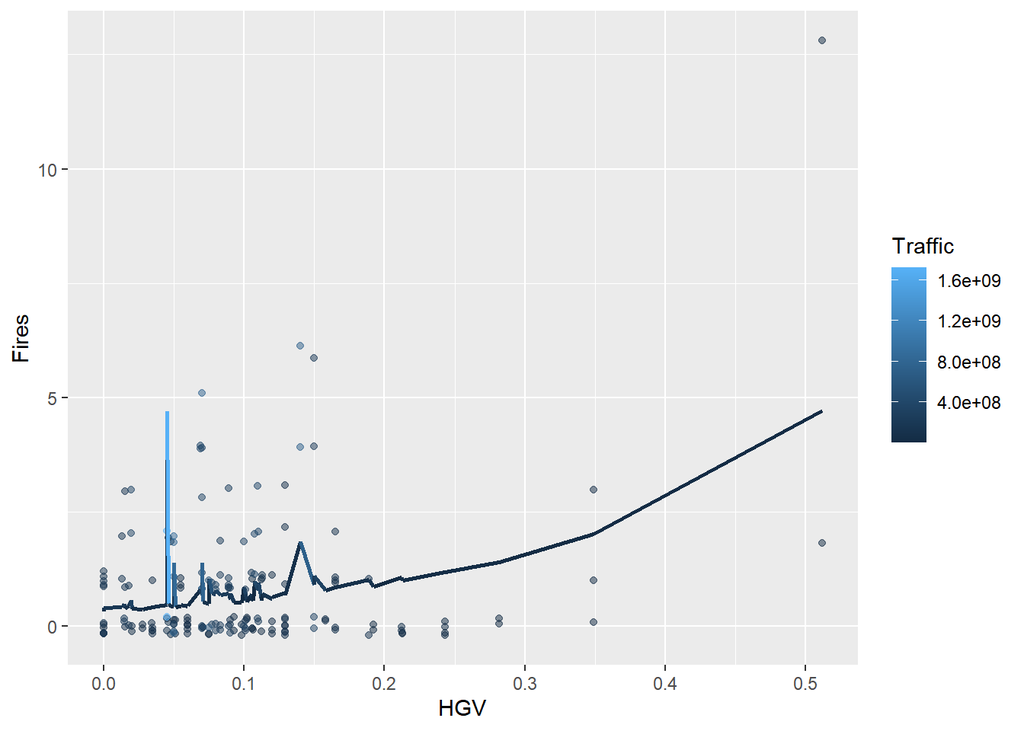

```r
Fires$hat <- predict(m2, type='response')
Fires <- Fires[with(Fires, order(Traffic, HGV)), ]
ggplot(Fires, aes(x = HGV, y = hat, colour = Traffic)) +
  geom_point(aes(y = Fires), alpha=.5, position=position_jitter(h=.2)) +
  geom_line(size = 1) +
  labs(x = "HGV", y = "Fires")
```

## Polynomial regression

With HGV, the summary is good, but the residuals don’t look very good when I plot them.

```r
glm.fit <- glm(Fires~poly(HGV, 3), data=Fires)
summary(glm.fit)
```

```
##
## Call:
## glm(formula = Fires ~ poly(HGV, 3), data = Fires)
##
## Deviance Residuals:
##     Min       1Q   Median       3Q      Max
## -5.4816  -0.8112  -0.4616   0.2113   5.5184
##
## Coefficients:
##               Estimate Std. Error t value Pr(>|t|)
## (Intercept)     0.8176     0.1026   7.969 2.43e-13 ***
## poly(HGV, 3)1   5.3837     1.3377   4.025 8.66e-05 ***
## poly(HGV, 3)2   6.1796     1.3377   4.619 7.68e-06 ***
## poly(HGV, 3)3   5.2079     1.3377   3.893 0.000143 ***
## ---
## Signif. codes:  0 '***' 0.001 '**' 0.01 '*' 0.05 '.' 0.1 ' ' 1
##
## (Dispersion parameter for gaussian family taken to be 1.789482)
##
##     Null deviance: 391.35  on 169  degrees of freedom
## Residual deviance: 297.05  on 166  degrees of freedom
## AIC: 587.32
##
## Number of Fisher Scoring iterations: 2
```

```r
confint(glm.fit)
```

```
## Attente de la réalisation du profilage...
```

```
##                   2.5 %   97.5 %
## (Intercept)   0.6165585 1.018736
## poly(HGV, 3)1 2.7617959 8.005544
## poly(HGV, 3)2 3.5576898 8.801438
## poly(HGV, 3)3 2.5860131 7.829761
```

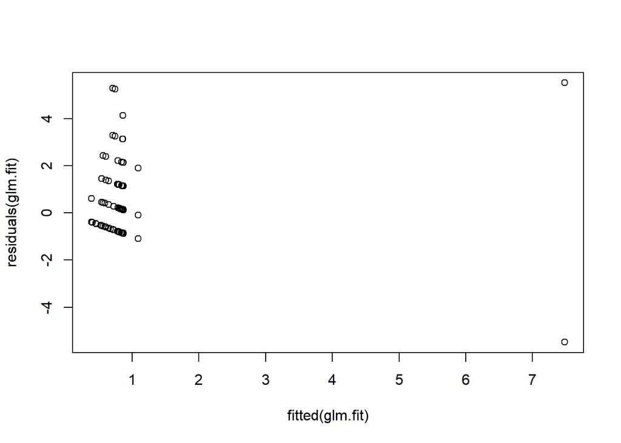

```r
plot(fitted(glm.fit), residuals(glm.fit))
```

The summary for Traffic isn’t as good as for HGV but the residuals look better.

```r
glm.fit2 <- glm(Fires~poly(Traffic, 3), data=Fires)
summary(glm.fit2)
```

```
##
## Call:
## glm(formula = Fires ~ poly(Traffic, 3), data = Fires)
##
## Deviance Residuals:
##     Min       1Q   Median       3Q      Max
## -2.5026  -0.6154  -0.4223   0.3480  12.5838
##
## Coefficients:
##                   Estimate Std. Error t value Pr(>|t|)
## (Intercept)         0.8176     0.1115   7.332 9.48e-12 ***
## poly(Traffic, 3)1   4.8132     1.4540   3.310  0.00114 **
## poly(Traffic, 3)2  -3.9016     1.4540  -2.683  0.00803 **
## poly(Traffic, 3)3  -1.4190     1.4540  -0.976  0.33054
## ---
## Signif. codes:  0 '***' 0.001 '**' 0.01 '*' 0.05 '.' 0.1 ' ' 1
##
## (Dispersion parameter for gaussian family taken to be 2.114126)
##
##     Null deviance: 391.35  on 169  degrees of freedom
## Residual deviance: 350.94  on 166  degrees of freedom
## AIC: 615.66
##
## Number of Fisher Scoring iterations: 2
```

```r
confint(glm.fit2)
```

```
## Attente de la réalisation du profilage...
```

```
##                        2.5 %    97.5 %
## (Intercept)        0.5990778  1.036216
## poly(Traffic, 3)1  1.9633557  7.662945
## poly(Traffic, 3)2 -6.7513681 -1.051779
## poly(Traffic, 3)3 -4.2687467  1.430842
```

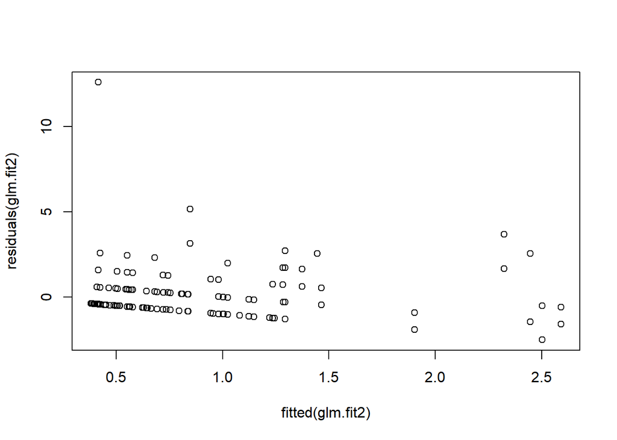

```r
plot(fitted(glm.fit2), residuals(glm.fit2))
```

## Variable selection ?

I think this part is not useful but anyway I let it.

```r
nullmodel <- lm(Fires ~ 1, data = Fires)
fullmodel <- lm(Fires ~ ., data = Fires)
```

Forward selection

```r
model.step.f <- step(nullmodel, scope = list(lower = nullmodel, upper = fullmodel), direction = 'forward')
```

```
## Start:  AIC=143.75
## Fires ~ 1
##
##             Df Sum of Sq    RSS    AIC
## + hat        1    73.173 318.17 110.56
## + Tunnel    91   280.347 111.00 111.53
## + Company   24   145.908 245.44 112.43
## + Length     1    31.354 359.99 131.55
## + HGV        1    28.984 362.36 132.66
## + Traffic    1    23.166 368.18 135.37
## + SlopeType  5    36.218 355.13 137.24
## + Urban      1     8.909 382.44 141.83
## <none>                   391.35 143.75
## + Slope      1     4.279 387.07 143.88
## + Direction  1     1.088 390.26 145.27
## + Limit      1     0.679 390.67 145.45
## + Type       1     0.209 391.14 145.66
##
## Step:  AIC=110.56
## Fires ~ hat
##
##             Df Sum of Sq    RSS    AIC
## + SlopeType  5    30.277 287.90 103.56
## + Urban      1    11.743 306.43 106.16
## + Length     1     6.006 312.17 109.32
## + Company   24    79.457 238.72 109.71
## <none>                   318.17 110.56
## + Slope      1     3.585 314.59 110.63
## + Tunnel    90   207.174 111.00 111.53
## + Direction  1     1.710 316.46 111.64
## + Type       1     1.075 317.10 111.98
## + Limit      1     0.303 317.87 112.39
## + HGV        1     0.110 318.06 112.50
## + Traffic    1     0.079 318.09 112.51
##
## Step:  AIC=103.56
## Fires ~ hat + SlopeType
##
##             Df Sum of Sq    RSS     AIC
## + Length     1    13.509 274.39  97.387
```

[output cut: 72 more lines]

```
## + Limit      1     0.859 181.62  83.238
## + Urban      1     0.023 182.45  84.019
## + Type       1     0.001 182.48  84.040
## + Tunnel    59    77.917 104.56 105.374
##
## Step:  AIC=81.91
## Fires ~ hat + SlopeType + Length + Company + Slope + Traffic +
##     HGV + Direction
##
##          Df Sum of Sq    RSS     AIC
## <none>                180.21  81.912
## + Limit   1     0.974 179.23  82.990
## + Urban   1     0.035 180.17  83.879
## + Type    1     0.028 180.18  83.885
## + Tunnel 59    77.716 102.49 103.974
```

Backward elimination

```r
model.step.b <- step(fullmodel, direction = 'backward')
```

```
## Start:  AIC=103.97
## Fires ~ Direction + Traffic + HGV + Slope + Urban + Type + Length +
##     Limit + SlopeType + Tunnel + Company + hat
##
##
## Step:  AIC=103.97
## Fires ~ Direction + Traffic + HGV + Slope + Urban + Type + Length +
##     Limit + SlopeType + Tunnel + Company
##
##
## Step:  AIC=103.97
## Fires ~ Direction + Traffic + HGV + Slope + Urban + Type + Length +
##     Limit + SlopeType + Tunnel
##
##
## Step:  AIC=103.97
## Fires ~ Direction + Traffic + HGV + Slope + Urban + Type + Length +
##     Limit + Tunnel
##
##
## Step:  AIC=103.97
## Fires ~ Direction + Traffic + HGV + Slope + Urban + Type + Length +
##     Tunnel
##
##
## Step:  AIC=103.97
## Fires ~ Direction + Traffic + HGV + Slope + Urban + Length +
##     Tunnel
##
##
## Step:  AIC=103.97
## Fires ~ Direction + Traffic + HGV + Slope + Length + Tunnel
##
##
## Step:  AIC=103.97
## Fires ~ Direction + Traffic + Slope + Length + Tunnel
##
##
## Step:  AIC=103.97
## Fires ~ Direction + Slope + Length + Tunnel
##
##             Df Sum of Sq    RSS    AIC
## <none>                   102.49 103.97
## - Length     1     1.483 103.97 104.42
## - Direction  1     2.070 104.56 105.37
## - Slope      1     4.902 107.39 109.92
## - Tunnel    91   251.838 354.33 132.85
```

Stepwise selection

```r
model.step <- step(nullmodel, scope = list(lower = nullmodel, upper = fullmodel), direction = 'both')
```

```
## Start:  AIC=143.75
## Fires ~ 1
##
##             Df Sum of Sq    RSS    AIC
## + hat        1    73.173 318.17 110.56
## + Tunnel    91   280.347 111.00 111.53
## + Company   24   145.908 245.44 112.43
## + Length     1    31.354 359.99 131.55
## + HGV        1    28.984 362.36 132.66
## + Traffic    1    23.166 368.18 135.37
## + SlopeType  5    36.218 355.13 137.24
## + Urban      1     8.909 382.44 141.83
## <none>                   391.35 143.75
## + Slope      1     4.279 387.07 143.88
## + Direction  1     1.088 390.26 145.27
## + Limit      1     0.679 390.67 145.45
## + Type       1     0.209 391.14 145.66
##
## Step:  AIC=110.56
## Fires ~ hat
##
##             Df Sum of Sq    RSS    AIC
## + SlopeType  5    30.277 287.90 103.56
## + Urban      1    11.743 306.43 106.16
## + Length     1     6.006 312.17 109.32
## + Company   24    79.457 238.72 109.71
## <none>                   318.17 110.56
## + Slope      1     3.585 314.59 110.63
## + Tunnel    90   207.174 111.00 111.53
## + Direction  1     1.710 316.46 111.64
## + Type       1     1.075 317.10 111.98
## + Limit      1     0.303 317.87 112.39
## + HGV        1     0.110 318.06 112.50
## + Traffic    1     0.079 318.09 112.51
## - hat        1    73.173 391.35 143.75
##
## Step:  AIC=103.56
## Fires ~ hat + SlopeType
##
##             Df Sum of Sq    RSS     AIC
```

[output cut: 106 more lines]

```
##
##             Df Sum of Sq    RSS     AIC
## <none>                   189.21  86.196
## + Direction  1     2.181 187.03  86.225
## - Limit      1     2.534 191.74  86.458
## + hat        1     1.172 188.03  87.140
## - Traffic    1     3.394 192.60  87.219
## + HGV        1     1.040 188.17  87.259
## - SlopeType  5    12.759 201.97  87.291
## + Urban      1     0.624 188.58  87.635
## + Type       1     0.583 188.62  87.672
## - Slope      1     4.913 194.12  88.554
## - Company   24    88.573 277.78 103.474
## - Length     1    23.650 212.86 104.219
## + Tunnel    60    84.645 104.56 105.374
```

AICs and BICs

```r
AIC(model.step.f)
```

```
## [1] 566.3509
```

```r
BIC(model.step.f)
```

```
## [1] 682.3754
```

```r
AIC(model.step.b)
```

```
## [1] 588.4135
```

```r
BIC(model.step.b)
```

```
## [1] 889.4502
```

```r
AIC(model.step)
```

```
## [1] 570.6355
```

```r
BIC(model.step)
```

```
## [1] 680.3885
```

## Trying other things that might be bad

```
##
## Call: gam(formula = Fires ~ Length - 1 + s(HGV), data = Fires)
## Deviance Residuals:
##     Min      1Q  Median      3Q     Max
## -5.8966 -0.7540 -0.4854  0.3140  5.1034
##
## (Dispersion Parameter for gaussian family taken to be 1.7923)
##
##     Null Deviance: 505 on 170 degrees of freedom
## Residual Deviance: 295.7308 on 165 degrees of freedom
## AIC: 588.5599
##
## Number of Local Scoring Iterations: NA
##
## Anova for Parametric Effects
##            Df  Sum Sq Mean Sq F value    Pr(>F)
## Length      1  84.692  84.692  47.253 1.222e-10 ***
## s(HGV)      1  52.208  52.208  29.129 2.321e-07 ***
## Residuals 165 295.731   1.792
## ---
## Signif. codes:  0 '***' 0.001 '**' 0.01 '*' 0.05 '.' 0.1 ' ' 1
##
## Anova for Nonparametric Effects
##        Npar Df Npar F    Pr(F)
## Length
## s(HGV)       3 10.925 1.39e-06 ***
## ---
## Signif. codes:  0 '***' 0.001 '**' 0.01 '*' 0.05 '.' 0.1 ' ' 1
```

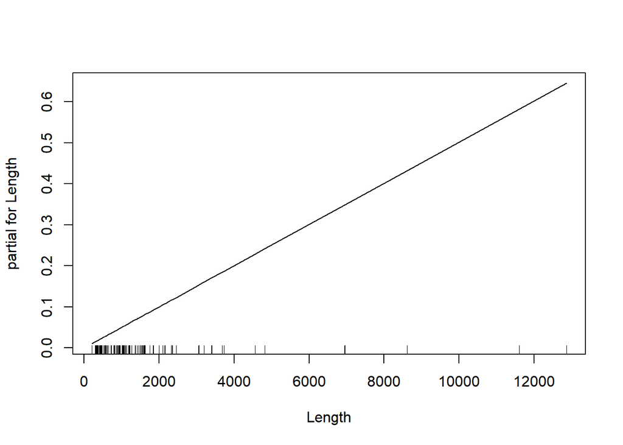

[figure not shown]

```
## [1] 588.5599
```

```
##
## Call: gam(formula = Fires ~ HGV - 1 + s(HGV), data = Fires)
## Deviance Residuals:
##     Min      1Q  Median      3Q     Max
## -5.8169 -0.7416 -0.5449  0.3044  5.1831
##
## (Dispersion Parameter for gaussian family taken to be 1.7898)
##
##     Null Deviance: 505 on 170 degrees of freedom
## Residual Deviance: 295.3202 on 165 degrees of freedom
## AIC: 588.3237
##
## Number of Local Scoring Iterations: NA
##
## Anova for Parametric Effects
##            Df  Sum Sq Mean Sq F value    Pr(>F)
## HGV         1 135.418 135.418 75.6603 3.272e-15 ***
## s(HGV)      1   0.946   0.946  0.5285    0.4683
## Residuals 165 295.320   1.790
## ---
## Signif. codes:  0 '***' 0.001 '**' 0.01 '*' 0.05 '.' 0.1 ' ' 1
##
## Anova for Nonparametric Effects
##        Npar Df Npar F     Pr(F)
## HGV
## s(HGV)       3 13.155 9.594e-08 ***
## ---
## Signif. codes:  0 '***' 0.001 '**' 0.01 '*' 0.05 '.' 0.1 ' ' 1
```

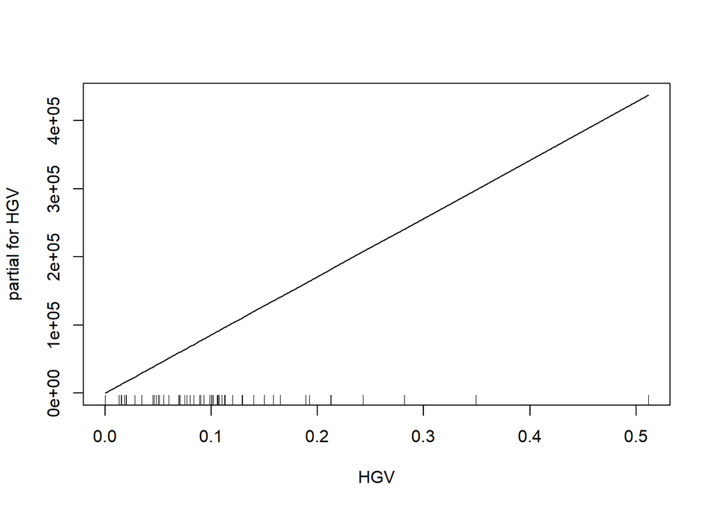

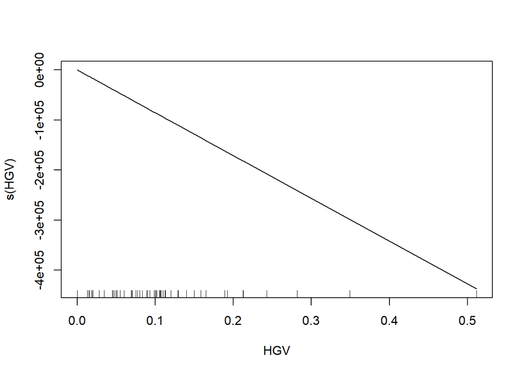

```
## [1] 588.3237
```

```r
#fit.gcv.re <- gam(Fires~s(Tunnel,bs="re")+s(HGV,by=Direction),data=Fires)
#summary(fit.gcv.re)
#gam.vcomp(fit.gcv.re)
#fit.gcv.re$aic
#plot(fit.gcv.re)
#plot(residuals(fit.gcv.re))
```

## Conlusion

I think that the best model is the Poisson model even though I am not sure it is very good. I am very bad at interpreting the residuals so if you are better at it it would help ! The Fires distribution clearly looks Poisson for me, so that’s why I tried to fit a Poisson model.  
I don’t know how to add the Tunnel and company to the model to make it be really interesting.  
I tried to fit things with gam like in the exercises sessions but again I am not an expert and I may have done useless things !

## References

On R commands  
https://bookdown.org/aurora_tumminello/statistics_lab/the-stock-market-data.html#data-exploration\

On modelling  
https://www.cetu.developpement-durable.gouv.fr/IMG/pdf/4-etude_pannes_accidents_et_incendies_pai_c._willmann_.pdf